# Infections of the body and the mind

**by [Ralf Martin](https://www.imperial.ac.uk/people/r.martin)[^1]**

The coronavirus pandemic has changed everything overnight. Unfortunately, as the genetic sequence of the virus started to make its deadly journey through bodies around the world, in parallel a memetic sequence emerged in the minds of some people: the idea that covid-19 pandemic is not real and a hoax. Indeed, the worry is that the two infections exist in a symbiotic relationship with one helping to advance the survival and spread of the other because widespread believe in Hoaxism might prevent people from following guidelines to limit the spread of the pandemic.

To monitor and study this phenomenon we (a team of Imperial College and LSE researchers) have been sampling tweets mentioning the terms “corona” and/or “covid”. Since March 23 we have collected 11.95 million tweets. We measure hoaxsism by looking for tweets with the hashtag #hoax (or #coronahoax, #covidhoax). There was a massive spike in hoaxism around the weekend of March 28 with hoax tweet rates of over 4% on some days. With the onset of April hoaxism declined to rates around 0.5%. Overall, we find a cumulate hoaxsim share of 0.5% for the UK and 0.7% for the UK.

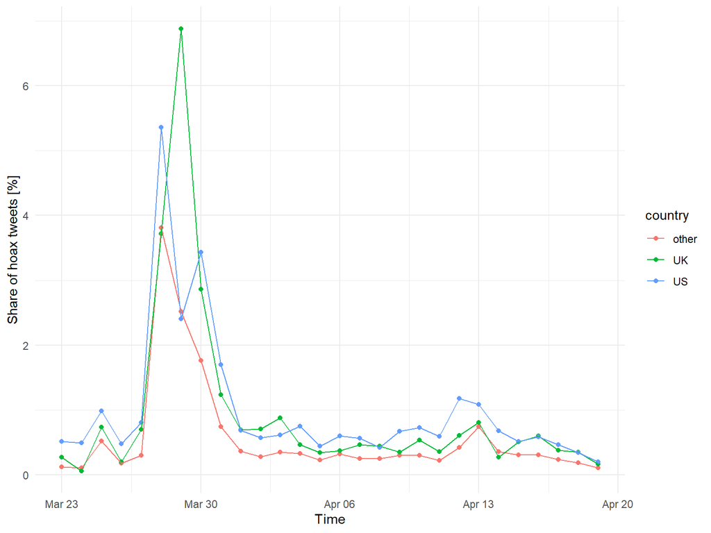

Figure 1: Hoaxism over time

What are the drivers hoaxism? One hypothesis is that hoaxism was driven by Donald Trump who had a vested interest in downplaying the crisis because of worries that the economic fallout could dampen his re-election chances. We can examine this by looking at word clouds of all tweets by prolific hoaxist tweeters:

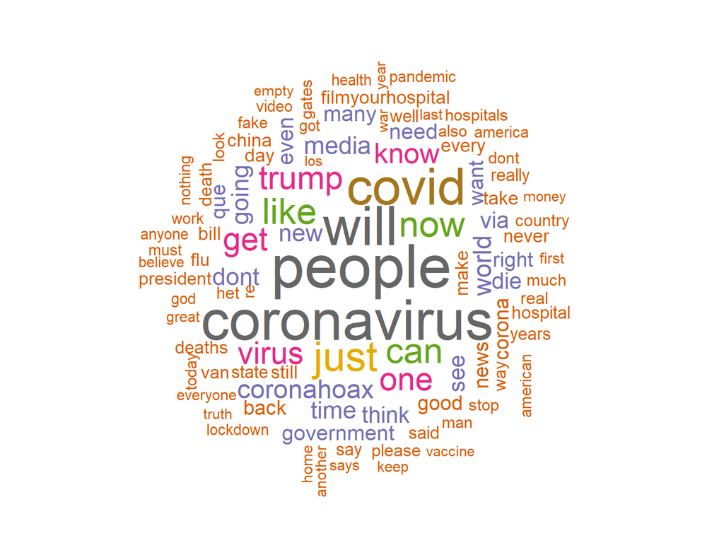

Figure 2: Word cloud of hoaxist’s tweets

We find that Trump is a popular term among hoaxists. Indeed, we find that his probability of being mentioned by hoaxists is significantly larger than among non hoaxist covid tweeters (7.93% as opposed to 3.06%)